# Data processing and statistics demo

Max Qiu, PhD  
Bioinformatician/Computational Biologist  
Bioinformatics Core Research Facility, Center for Biotechnology  
Data Life Science Core, NCIBC  
[maxqiu@unl.edu]  
BEAD E206, UNL, 68588-0665

- Assess the quality of data: missing values
- Assess feature presence/absence: missing value imputation
- High-dimensional data processing
  - Log2 transformation
  - Normalization
  - Scaling

**Goal: feature selection/extraction**

```r
suppressPackageStartupMessages(library("tidyverse"))
```

Set working directory where the data is.

```r
setwd("./demo/")
```

Import data and data wrangling.

```r
fh = read.csv(file = "malaria_feature_table.csv", header = TRUE, row.names = 1, stringsAsFactors = FALSE) %>%
    as.data.frame()

head(fh)
dim(fh)
```

A data.frame: 6 × 12

|  | Naive_007 <chr> | Naive_027 <chr> | Naive_071 <chr> | Naive_109 <chr> | Naive_127 <chr> | Naive_139 <chr> | Semi_025 <chr> | Semi_045 <chr> | Semi_061 <chr> | Semi_091 <chr> | Semi_143 <chr> | Semi_157 <chr> |
| --- | --- | --- | --- | --- | --- | --- | --- | --- | --- | --- | --- | --- |
| Label | Naive | Naive | Naive | Naive | Naive | Naive | Semi_immue | Semi_immue | Semi_immue | Semi_immue | Semi_immue | Semi_immue |
| 85.065__24.64 | 166020.82174 | 120086.08327 | 19509.14147 | 118112.9565 | 87039.61996 | 104898.32903 | 152651.82014 | 65984.36172 | 149758.85754 | 98183.45473 | 97731.15547 | 128301.02182 |
| 85.0843__167.65 | 1645008.20686 | 1190622.95729 | 638456.21528 | 0 | 1629532.41894 | 425340.44229 | 2314313.37182 | 2527459.04192 | 3709995.77534 | 3293045.43331 | 2888648.78287 | 3762183.05657 |
| 86.0602__37.16 | 18142.47554 | 16616.03235 | 10886.52278 | 0 | 0 | 40055.58588 | 1212986.02473 | 661407.86422 | 1393239.74513 | 1148858.71605 | 1007422.72639 | 1967635.53434 |
| 86.0602__129.2 | 757420.68035 | 1401437.3743 | 986969.31026 | 2559178.25865 | 1720322.70316 | 927659.48141 | 3910272.07896 | 3044111.48558 | 3490387.75572 | 2757396.23265 | 1869315.63359 | 4231258.08127 |
| 86.0603__31.13 | 40168.41032 | 28760.74122 | 40007.49015 | 2115.15429 | 30082.36671 | 83055.68507 | 1880331.86961 | 925490.77154 | 2595342.86486 | 1578033.85219 | 1137072.88981 | 2198041.28858 |

1. 5114

2. 12

```r
fh <- fh[,order(fh["Label",])] ## order samples by group
labels_d1 <- as.matrix(fh[1,])
```

Check what we have in our global environment.

```r
ls()
```

1. 'fh'

2. 'labels_d1'

## Check missing data.

```r
d1 <- fh[-1,] # removing label from the dataset, just data left.

sum(d1==0) ## Total missing values
sum(d1 ==0)/(dim(d1)[1]*dim(d1)[2])
```

10448

0.170284894712824

The dataset contains 10448 missing values, missing data percentage is 17%, which is acceptable for raw peak intensity table. We want to convert all zeros to NA.

```r
d1[d1 == 0] <- NA ## Change zeros to NA
sum(is.na(d1))
```

10448

## Access feature presence/absence.

As we stated, a feature is deemed present when missing values of a feature accounts for less than 50% of sample space, all sample or within each group.

```r
d1$nacount <- as.matrix(apply(d1, 1, function(x) sum(is.na(x)))) #count the missing signal values by feature
d1$nacount_Native = as.matrix(apply(d1[, 1:6], 1, function(x) sum(is.na(x))))
d1$nacount_Semi = as.matrix(apply(d1[, 7:12], 1, function(x) sum(is.na(x))))

head(d1)
```

A data.frame: 6 × 15

|  | Naive_007 <chr> | Naive_027 <chr> | Naive_071 <chr> | Naive_109 <chr> | Naive_127 <chr> | Naive_139 <chr> | Semi_025 <chr> | Semi_045 <chr> | Semi_061 <chr> | Semi_091 <chr> | Semi_143 <chr> | Semi_157 <chr> | nacount <int[,1]> | nacount_Native <int[,1]> | nacount_Semi <int[,1]> |
| --- | --- | --- | --- | --- | --- | --- | --- | --- | --- | --- | --- | --- | --- | --- | --- |
| 85.065__24.64 | 166020.82174 | 120086.08327 | 19509.14147 | 118112.9565 | 87039.61996 | 104898.32903 | 152651.82014 | 65984.36172 | 149758.85754 | 98183.45473 | 97731.15547 | 128301.02182 | 0 | 0 | 0 |
| 85.0843__167.65 | 1645008.20686 | 1190622.95729 | 638456.21528 | NA | 1629532.41894 | 425340.44229 | 2314313.37182 | 2527459.04192 | 3709995.77534 | 3293045.43331 | 2888648.78287 | 3762183.05657 | 1 | 1 | 0 |
| 86.0602__37.16 | 18142.47554 | 16616.03235 | 10886.52278 | NA | NA | 40055.58588 | 1212986.02473 | 661407.86422 | 1393239.74513 | 1148858.71605 | 1007422.72639 | 1967635.53434 | 2 | 2 | 0 |
| 86.0602__129.2 | 757420.68035 | 1401437.3743 | 986969.31026 | 2559178.25865 | 1720322.70316 | 927659.48141 | 3910272.07896 | 3044111.48558 | 3490387.75572 | 2757396.23265 | 1869315.63359 | 4231258.08127 | 0 | 0 | 0 |
| 86.0603__31.13 | 40168.41032 | 28760.74122 | 40007.49015 | 2115.15429 | 30082.36671 | 83055.68507 | 1880331.86961 | 925490.77154 | 2595342.86486 | 1578033.85219 | 1137072.88981 | 2198041.28858 | 0 | 0 | 0 |
| 86.0966__58.82 | 95507679.62103 | 88613771.10909 | 71913129.46904 | NA | 2871361.94795 | 120978190.73858 | 124289527.10497 | 193556499.1973 | 184419890.82983 | 140838594.43458 | 167559323.738 | 176065595.45387 | 1 | 1 | 0 |

Scenario 1, keep a feature when it has na less than 50% of all samples.

```r
d2 <- d1[which(d1$nacount < round((length(d1)-3)*.5)), ] %>%
        select(-c(nacount, nacount_Semi, nacount_Native))
sum(is.na(d2)) # number of missing values
sum(is.na(d2))/(dim(d2)[1]*dim(d2)[2]) # percentage missing data
```

3001

0.0582808980035734

Scenario 2, keep a feature when it has na less than 50% of either group.

```r
d2_2 = d1[which(d1$nacount_Native < round(6*.5) & d1$nacount_Semi < round(6*.5)), ] %>%
        select(-c(nacount, nacount_Semi, nacount_Native))
sum(is.na(d2_2)) # number of missing values
sum(is.na(d2_2))/(dim(d2_2)[1]*dim(d2_2)[2]) # percentage missing data
```

1111

0.0241984666318174

## Missing data imputation.

```r
# decide K (how many neighbor to use)
k <- d2_2 %>% length() %>% sqrt() # square root of number of features
if (k>=3){
        if (is.integer(k)) k = k else k = ceiling(k)
} else {k = 3}

k
```

4

Scenario 1:

```r
imputed_meta_d1 <- impute::impute.knn(as.matrix(d2), k = k, rowmax = 0.5,
                              colmax = 0.8, maxp = 1500)

imputed_d1 <- as.data.frame(imputed_meta_d1[["data"]], colnames = TRUE)
sum(imputed_d1 == 0)
sum(imputed_d1 < 0)
```

```
Cluster size 4291 broken into 39 4252
Done cluster 39
Cluster size 4252 broken into 196 4056
Done cluster 196
Cluster size 4056 broken into 340 3716
Done cluster 340
Cluster size 3716 broken into 3115 601
Cluster size 3115 broken into 827 2288
Done cluster 827
Cluster size 2288 broken into 3 2285
Done cluster 3
Cluster size 2285 broken into 1855 430
Cluster size 1855 broken into 501 1354
Done cluster 501
Done cluster 1354
Done cluster 1855
Done cluster 430
Done cluster 2285
Done cluster 2288
Done cluster 3115
Done cluster 601
Done cluster 3716
Done cluster 4056
Done cluster 4252
```

8

0

There is 8 zeros after imputation. This usually means there were too much missing values to begin with, and we are pushing the limit of KNN.

Scenatio 2:

```r
imputed_meta_d1 <- impute::impute.knn(as.matrix(d2_2), k = k, rowmax = 0.5,
                              colmax = 0.8, maxp = 1500)

imputed_d1 <- as.data.frame(imputed_meta_d1[["data"]], colnames = TRUE)
sum(imputed_d1 == 0)
sum(imputed_d1 < 0)
```

```
Cluster size 3826 broken into 3776 50
Cluster size 3776 broken into 3599 177
Cluster size 3599 broken into 3266 333
Cluster size 3266 broken into 572 2694
Done cluster 572
Cluster size 2694 broken into 2083 611
Cluster size 2083 broken into 712 1371
Done cluster 712
Done cluster 1371
Done cluster 2083
Done cluster 611
Done cluster 2694
Done cluster 3266
Done cluster 333
Done cluster 3599
Done cluster 177
Done cluster 3776
Done cluster 50
```

0

0

There is no missing values after imputation for scenario 2, so this is the data we will continue with. Check the data distribution after imputation.

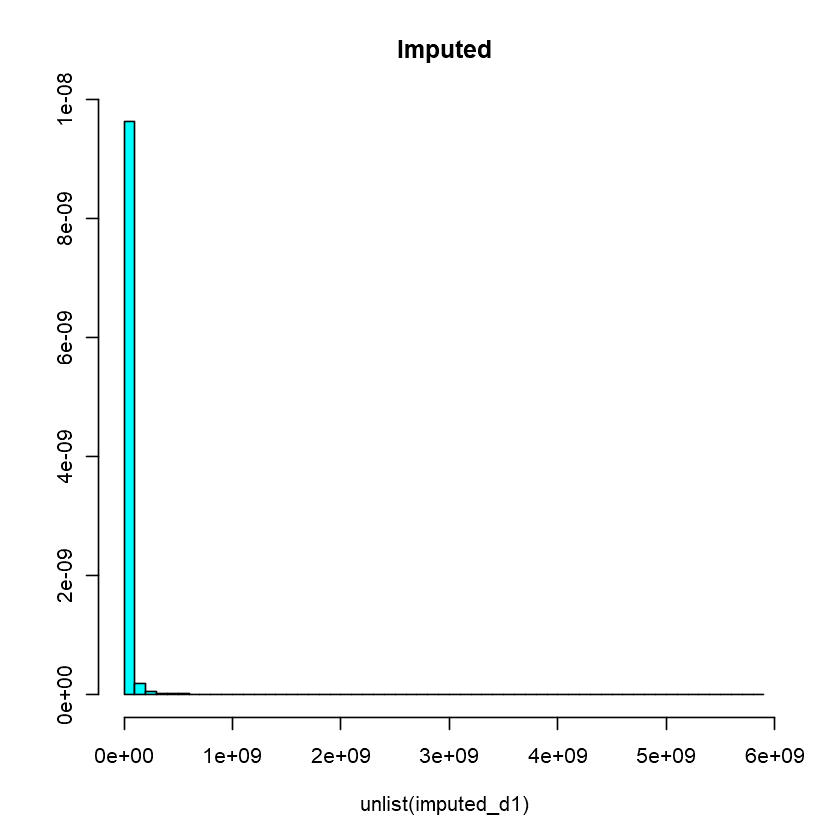

```r
MASS::truehist(unlist(imputed_d1), main = "Imputed", nbins = 50) # check data distribution
```

This distribution is very typical for mass spec-generated data. Next step is data processing.

## Log2 transformation.

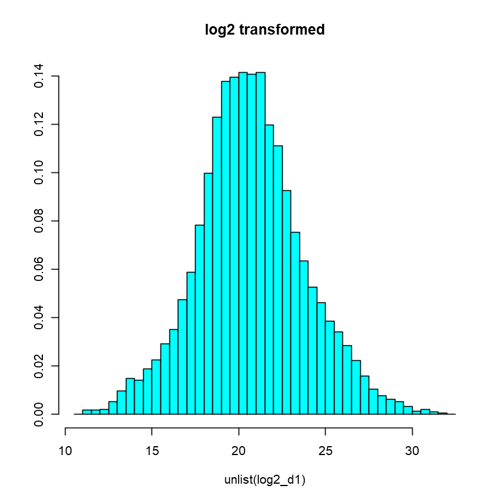

**Semi_061101**

30709

**Naive_027101**

3927

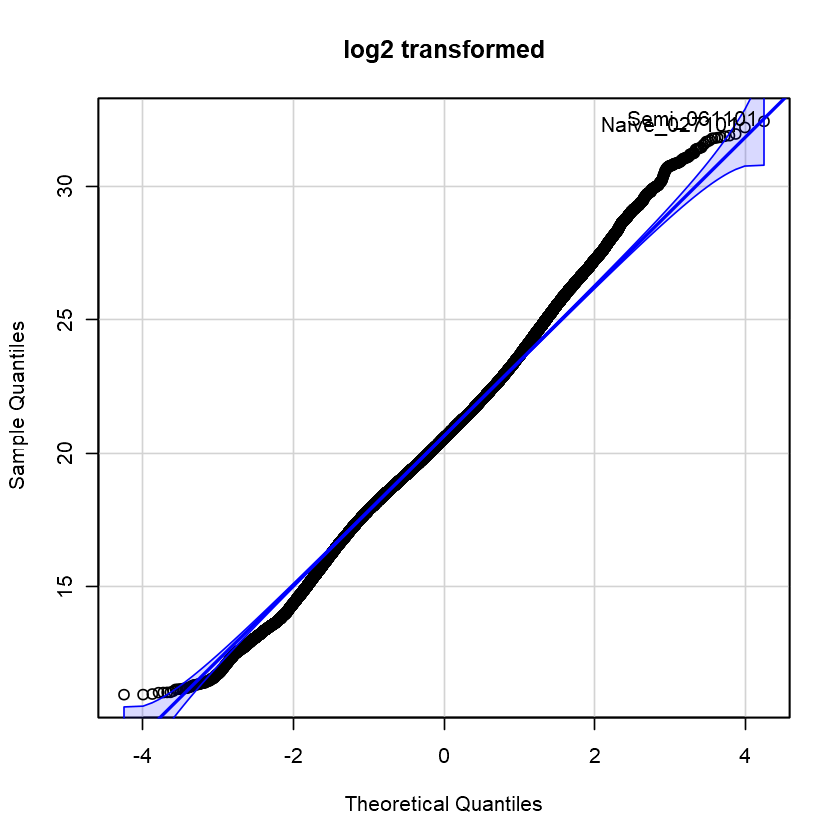

```r
log2_d1 <- log2(type.convert(imputed_d1))
MASS::truehist(unlist(log2_d1), main = "log2 transformed", nbins = 50) # check data distribution
car::qqPlot(unlist(log2_d1), main = "log2 transformed",xlab = "Theoretical Quantiles", ylab = "Sample Quantiles")
```

This already improves the data distribution quite a lot. But for the sake of demonstration, we will proceed with eigenMS normalization, which is implemented using package `ProteoMM`. Again, `ProteoMM` is a bioconductor package.

## EigenMS normalization

```r
if (!requireNamespace("BiocManager", quietly = TRUE))
    install.packages("BiocManager")

if (!requireNamespace("ProteoMM", quietly = TRUE))
    BiocManager::install("ProteoMM")

suppressPackageStartupMessages(library("ProteoMM"))
```

```r
d4 <- cbind.data.frame(row.names(log2_d1), log2_d1) # check data structure, feature by sample
head(d4)
```

A data.frame: 6 × 13

|  | row.names(log2_d1) <chr> | Naive_007 <dbl> | Naive_027 <dbl> | Naive_071 <dbl> | Naive_109 <dbl> | Naive_127 <dbl> | Naive_139 <dbl> | Semi_025 <dbl> | Semi_045 <dbl> | Semi_061 <dbl> | Semi_091 <dbl> | Semi_143 <dbl> | Semi_157 <dbl> |
| --- | --- | --- | --- | --- | --- | --- | --- | --- | --- | --- | --- | --- | --- |
| 85.065__24.64 | 85.065__24.64 | 17.34100 | 16.87371 | 14.25186 | 16.84981 | 16.40938 | 16.67863 | 17.21989 | 16.00984 | 17.19228 | 16.58319 | 16.57653 | 16.96917 |
| 85.0843__167.65 | 85.0843__167.65 | 20.64966 | 20.18329 | 19.28423 | 20.14395 | 20.63603 | 18.69826 | 21.14215 | 21.26926 | 21.82299 | 21.65099 | 21.46196 | 21.84314 |
| 86.0602__37.16 | 86.0602__37.16 | 14.14708 | 14.02029 | 13.41026 | 17.59752 | 17.49065 | 15.28972 | 20.21013 | 19.33518 | 20.41001 | 20.13177 | 19.94224 | 20.90803 |
| 86.0602__129.2 | 86.0602__129.2 | 19.53074 | 20.41848 | 19.91265 | 21.28725 | 20.71425 | 19.82324 | 21.89884 | 21.53759 | 21.73496 | 21.39488 | 20.83408 | 22.01266 |
| 86.0603__31.13 | 86.0603__31.13 | 15.29377 | 14.81181 | 15.28798 | 11.04655 | 14.87663 | 16.34179 | 20.84256 | 19.81986 | 21.30749 | 20.58970 | 20.11689 | 21.06779 |
| 86.0966__58.82 | 86.0966__58.82 | 26.50911 | 26.40103 | 26.09975 | 26.55729 | 21.45330 | 26.85017 | 26.88913 | 27.52818 | 27.45842 | 27.06947 | 27.32010 | 27.39154 |

This following section of code is based on `ProteoMM` documentation. You can browse package vignette by typing this line of code in R console: `browseVignettes("ProteoMM")`

[output not shown]

[output cut: 73 more lines]

[output not shown]

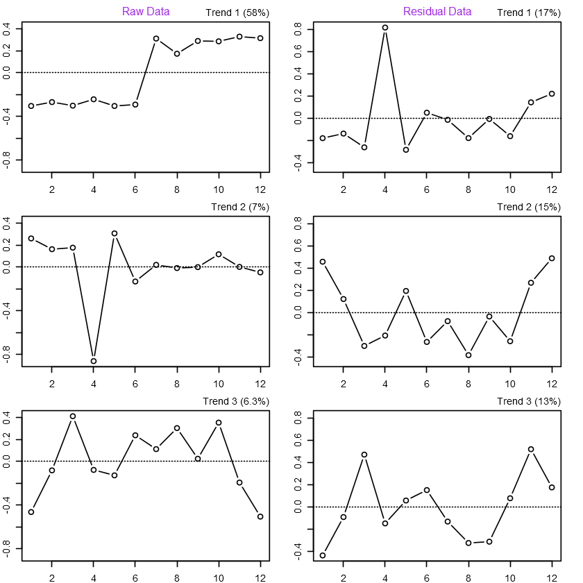

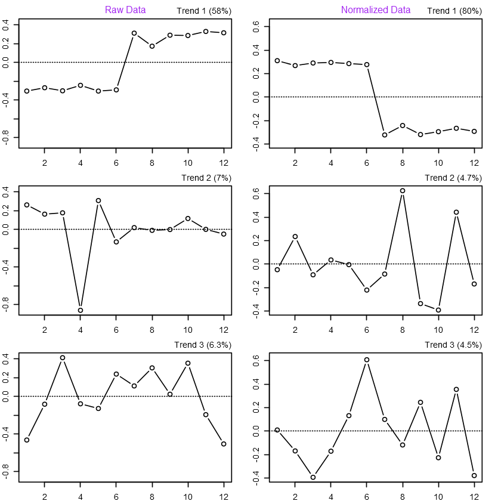

```r
rowmeta <- d4[1,]
rowmeta2 <- as.data.frame(t(colnames(d4)))
colmeta <- d4[-1,1]

intsCols <- 2:dim(d4)[2]
m_logInts = ProteoMM::make_intencities(d4, intsCols)

metaCols <- 1
m_mets.info = as.matrix(ProteoMM::make_meta(d4, metaCols))

grps = as.factor(t(labels_d1))
m_nummiss = sum(is.na(m_logInts)) #check zeros

set.seed(42)
hs_m_ints_eig1 = eig_norm1(m=m_logInts,treatment = grps,
                           prot.info=m_mets.info)
hs_m_ints_norm_1bt = eig_norm2(rv=hs_m_ints_eig1)
```

The dataframe after eigenMS normalization is named `norm_d1`, and we will check its distribution as well.

```r
norm_d1 <- as.data.frame(hs_m_ints_norm_1bt[["norm_m"]])
par(mfrow=c(1,1)) # after last step, the R graphic space are devided to 3 by 2 grid, this step is simply to restore.
```

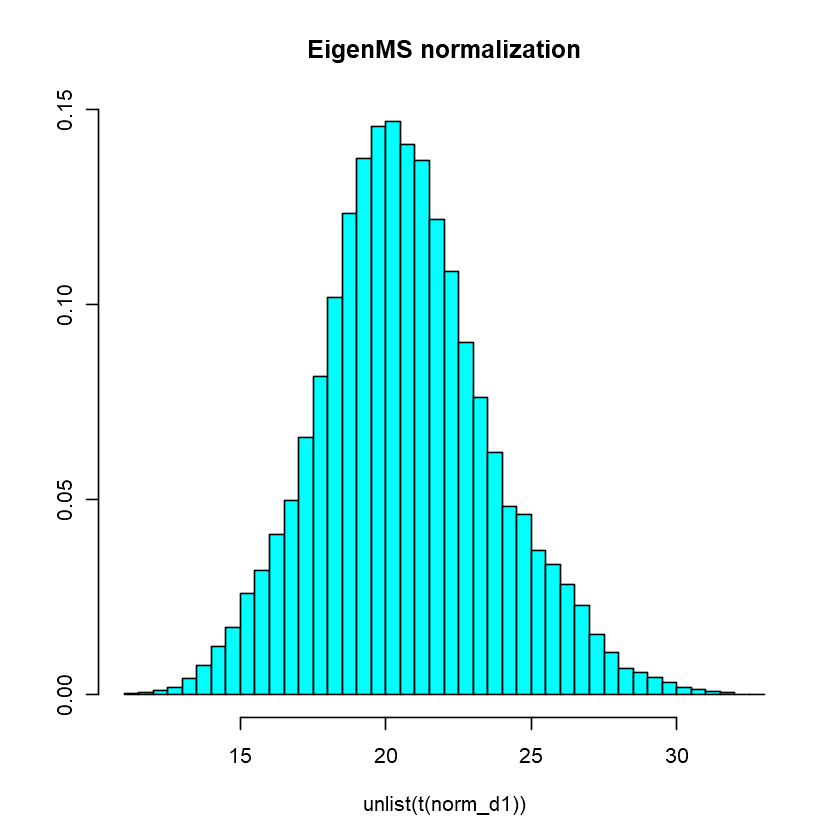

1. 3262

2. 1209

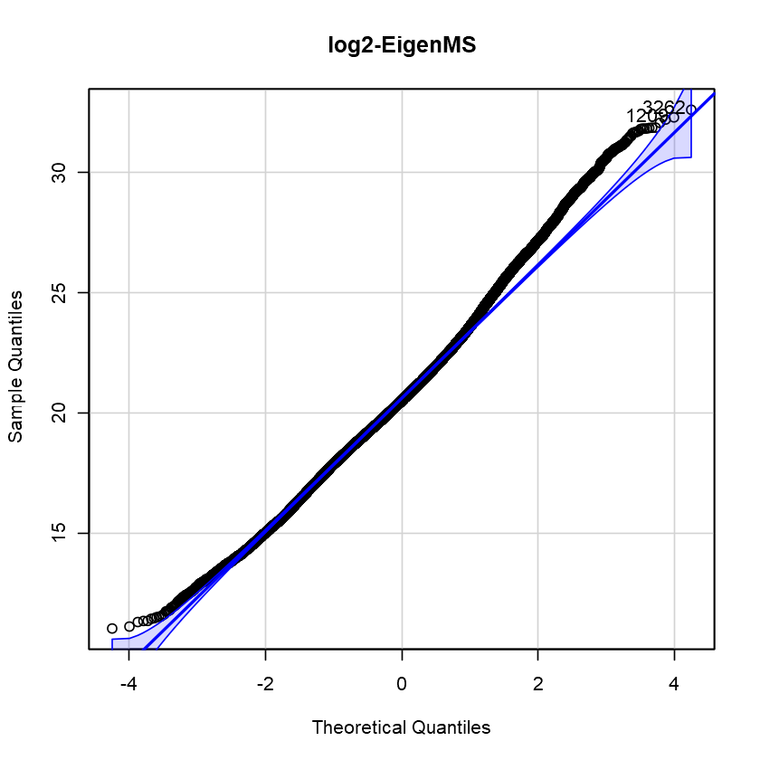

```r
MASS::truehist(unlist(t(norm_d1)), main = "EigenMS normalization", nbins = 50)
car::qqPlot(unlist(t(norm_d1)),main = "log2-EigenMS",xlab = "Theoretical Quantiles", ylab = "Sample Quantiles")
```

This data distribution looks normal based on histogram and qq plot, so we will stop here and proceed with univariate and multivariate analysis.

Other normalization methods include rank invariant normalization implemented using `lumi`, cubic spline normalization implemented using `affy`. If normalization step cannot transform the data to a near Gaussian distribution, we will follow up with scaling step, implemented using `MetaboAnalyze`.

## Univariate analysis, t-test and Wilcoxon rank sum test.

```r
d5 <- rbind.data.frame(labels_d1, norm_d1)

C <- d5[-1,which(d5[1,]=="Naive")]; P <- d5[-1,which(d5[1,]=="Semi_immue")]

wt <- data.frame(Doubles=double(),Doubles=double(),Doubles=double(),Doubles=double(),Doubles=double())

# Calculate p-values from both t-test and Wilcoson rank sum test.
# P-values will need to be adjusted with Benjamini-Hochberg correction (i.e., FDR)
for (i in 1:dim(norm_d1)[1]){
        wt[i,1] <- t.test(type.convert(t(P[i,])),type.convert(t(C[i,])))$p.value
        wt[i,3] <- wilcox.test(type.convert(t(P[i,])),type.convert(t(C[i,])))$p.value
        az1 <- 2^(type.convert(C[i,])); az1L <- length(az1)
        az2 <- 2^(type.convert(P[i,])); az2L <- length(az2)
        wt[i,5] <- gtools::foldchange(sum(az2)/az2L, sum(az1)/az1L)
        #print(az1)
}
wt[,2] <- as.data.frame(p.adjust(wt[,1], method = 'BH'))#, n = length(p))
wt[,4] <- as.data.frame(p.adjust(wt[,3], method = 'BH'))#, n = length(p))

colnames(wt) <- c("pT", "BHT", "pW", "BHW", "FC(lin)")
row.names(wt) <- rownames(norm_d1)

# Calculate log2FoldChange
log2FoldChange =gtools::foldchange2logratio(wt$`FC(lin)`,base = 2)
wt = cbind(wt,log2FoldChange)
head(wt)
```

A data.frame: 6 × 6

|  | pT <dbl> | BHT <dbl> | pW <dbl> | BHW <dbl> | FC(lin) <dbl> | log2FoldChange <dbl> |
| --- | --- | --- | --- | --- | --- | --- |
| 85.065__24.64 | 2.226306e-01 | 2.555610e-01 | 0.179653680 | 0.210715812 | 1.213459 | 0.2791252 |
| 85.0843__167.65 | 4.187692e-07 | 2.748269e-06 | 0.002164502 | 0.003519501 | 3.033145 | 1.6008146 |
| 86.0602__37.16 | 1.753456e-09 | 4.563756e-08 | 0.002164502 | 0.003519501 | 28.009632 | 4.8078511 |
| 86.0602__129.2 | 2.976478e-05 | 8.392046e-05 | 0.002164502 | 0.003519501 | 2.428051 | 1.2797987 |
| 86.0603__31.13 | 2.805323e-08 | 3.496145e-07 | 0.002164502 | 0.003519501 | 64.747532 | 6.0167533 |
| 86.0966__58.82 | 2.142860e-05 | 6.370305e-05 | 0.002164502 | 0.003519501 | 3.150434 | 1.6555504 |

```r
sum(wt[,1] < 0.05 & wt[,3] < 0.05)
sum(wt[,2] < 0.01 & wt[,4] < 0.01)
sig_wt <- wt[which(wt[,2] < 0.01 & wt[,4] < 0.01),]
head(sig_wt)
dim(sig_wt)
```

2895

2448

A data.frame: 6 × 6

|  | pT <dbl> | BHT <dbl> | pW <dbl> | BHW <dbl> | FC(lin) <dbl> | log2FoldChange <dbl> |
| --- | --- | --- | --- | --- | --- | --- |
| 85.0843__167.65 | 4.187692e-07 | 2.748269e-06 | 0.002164502 | 0.003519501 | 3.033145 | 1.600815 |
| 86.0602__37.16 | 1.753456e-09 | 4.563756e-08 | 0.002164502 | 0.003519501 | 28.009632 | 4.807851 |
| 86.0602__129.2 | 2.976478e-05 | 8.392046e-05 | 0.002164502 | 0.003519501 | 2.428051 | 1.279799 |
| 86.0603__31.13 | 2.805323e-08 | 3.496145e-07 | 0.002164502 | 0.003519501 | 64.747532 | 6.016753 |
| 86.0966__58.82 | 2.142860e-05 | 6.370305e-05 | 0.002164502 | 0.003519501 | 3.150434 | 1.655550 |
| 86.0966__93.94 | 2.403083e-05 | 7.029202e-05 | 0.002164502 | 0.003519501 | 4.328769 | 2.113957 |

1. 2448

2. 6

There are 2448 features that are significant different when comparing the two groups.

## Multivariate analysis, PCA

```r
if (!requireNamespace("pcaMethods", quietly = TRUE))
    BiocManager::install("pcaMethods")

suppressPackageStartupMessages(library("pcaMethods"))
```

```r
pc = pcaMethods::pca(t(norm_d1), nPcs = 9, method = "svd", scale = "pareto", center = TRUE)

pca = rbind.data.frame(labels_d1, norm_d1) %>%
        t(.) %>%
        as.data.frame(.) %>%
        rownames_to_column(.) %>%
        as_tibble(.) %>%
        select(rowname, Label) %>%
        column_to_rownames(.,var = "rowname") %>%
        merge(., pcaMethods::scores(pc), by=0)
```

### Score plot

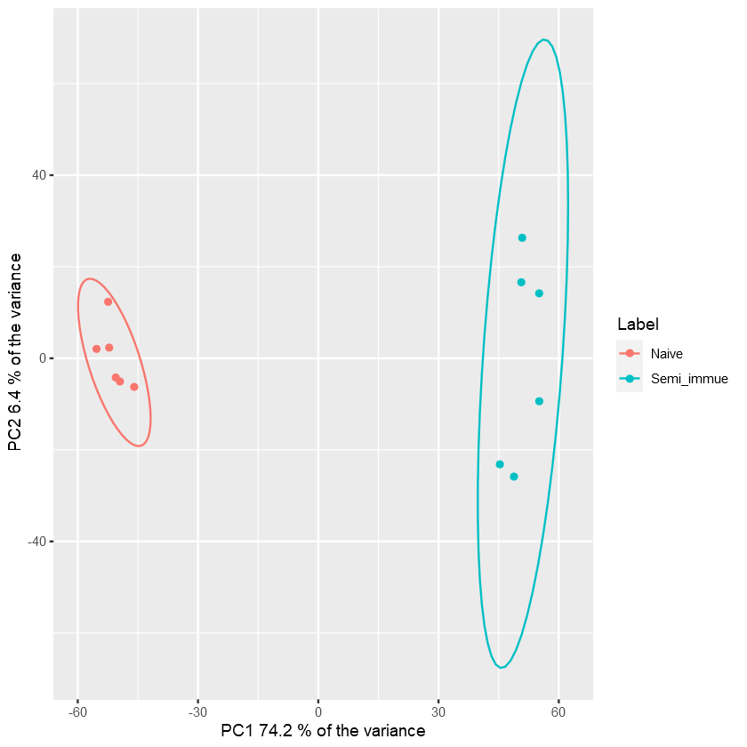

```r
ggplot(pca, aes(PC1, PC2,colour=Label)) + geom_point() + stat_ellipse() +
        xlab(paste("PC1", round(pc@R2[1] * 100, digits = 1), "% of the variance")) +
        ylab(paste("PC2", round(pc@R2[2] * 100, digits = 1), "% of the variance"))
```

As is shown in score plot, there are clear separation between these two groups, and the first PC accounts for ~74% of total variance of the dataset. The ellipses represent 95% confidence intervals.

### Scree plot

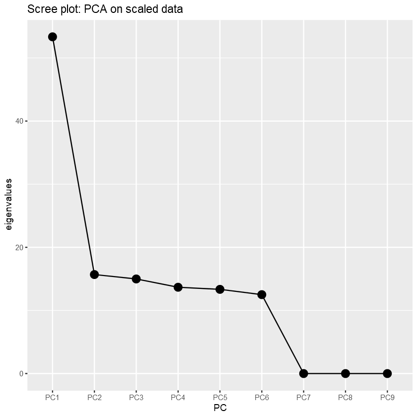

```r
var_explained_pc = data.frame(PC = paste0("PC", 1:9), var_explained = (pc@sDev)^2/sum((pc@sDev)^2), eigenvalues = pc@sDev)
var_explained_pc %>%
        ggplot(aes(x=PC,y=eigenvalues, group=1))+
        geom_point(size=4)+
        geom_line()+
        labs(title="Scree plot: PCA on scaled data")
```

As PC1 accounts for majority of the variance in the dataset, we should take a look at what features count heavier in this PC.

### Loading plot

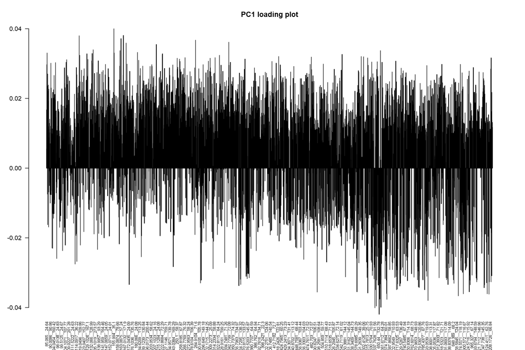

```r
options(repr.plot.width=15, repr.plot.height=10)
barplot( pc@loadings[,1], main = "PC1 loading plot", las = 2, cex.names=0.6)
```

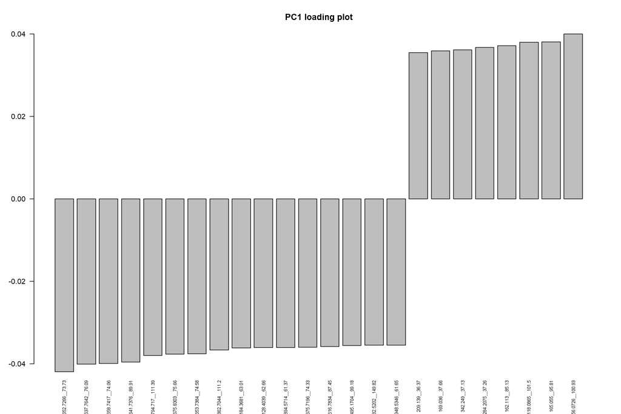

```r
barplot( sort( pc@loadings[,1][which(abs(pc@loadings[,1]) > 0.035)], decreasing = FALSE), main = "PC1 loading plot", las = 2, cex.names=0.6)
```

How many features here? And their names?

```r
length(  sort( pc@loadings[,1][which(abs(pc@loadings[,1]) > 0.035)], decreasing = FALSE) )
names( sort( pc@loadings[,1][which(abs(pc@loadings[,1]) > 0.035)], decreasing = FALSE) )
```

24

1. '652.7266__73.73'

2. '637.7642__76.09'

3. '658.7417__74.06'

4. '641.7376__89.91'

5. '794.717__111.39'

6. '675.8303__75.66'

7. '653.7384__74.58'

8. '862.7044__111.2'

9. '1184.3681__63.01'

10. '1128.4039__62.66'

11. '894.5714__61.37'

12. '675.7196__74.33'

13. '616.7834__87.45'

14. '495.1704__99.18'

15. '582.5202__149.82'

16. '948.5346__61.65'

17. '209.139__36.37'

18. '169.036__37.66'

19. '342.249__37.13'

20. '284.2075__37.26'

21. '162.113__85.13'

22. '118.0865__101.5'

23. '165.055__95.81'

24. '156.0726__100.93'